# Chapter 3 - Logistic Regression

Fri 13 Nov 2020

## Loading the alcohol data set

From data/alc.csv file:

```r
alc<-read.csv("data/alc.csv")
print(dim(alc))
```

```
## [1] 382  35
```

**A quick overview of the contents in this data:** This is a student performance vs alcohol usage survey data. Data is joined from two course survey data sets, scores averaged, from 382 distinct students with both Portugese and math courses. Added average numberic column alc_use for average alcohol consumption (likert 0…5) and logical column high_use (which is TRUE if alc_use is higher than 2).

```r
colnames(alc)
```

```
##  [1] "school"     "sex"        "age"        "address"    "famsize"
##  [6] "Pstatus"    "Medu"       "Fedu"       "Mjob"       "Fjob"
## [11] "reason"     "nursery"    "internet"   "guardian"   "traveltime"
## [16] "studytime"  "failures"   "schoolsup"  "famsup"     "paid"
## [21] "activities" "higher"     "romantic"   "famrel"     "freetime"
## [26] "goout"      "Dalc"       "Walc"       "health"     "absences"
## [31] "G1"         "G2"         "G3"         "alc_use"    "high_use"
```

Data contains school performance scores (Grades after periods 1-3), absences, alcohol use and some binary background data such as school name, gender, age, home location type. Numeric likert-scale estimates (from 1 to 5 values) on family relations, freetime activity, going out and health. More information at: https://archive.ics.uci.edu/ml/datasets/Student+Performance * NB! added alcohol use columns (average and logical (high consumption))

## Hypothesis about high alochol consumption

Alcohol might be consumed at high rate if the initial G1 grades are low and family relations are at low level. Also stated male gender  
and higher age might induce high alcohol usage.

A graphical summary:

[figure not shown]

```r
library(GGally)
ggpairs(alc,
        columns = c('alc_use','age','sex','famrel','G1'),
        lower = list(combo = wrap("facethist", bins = 30)))
```

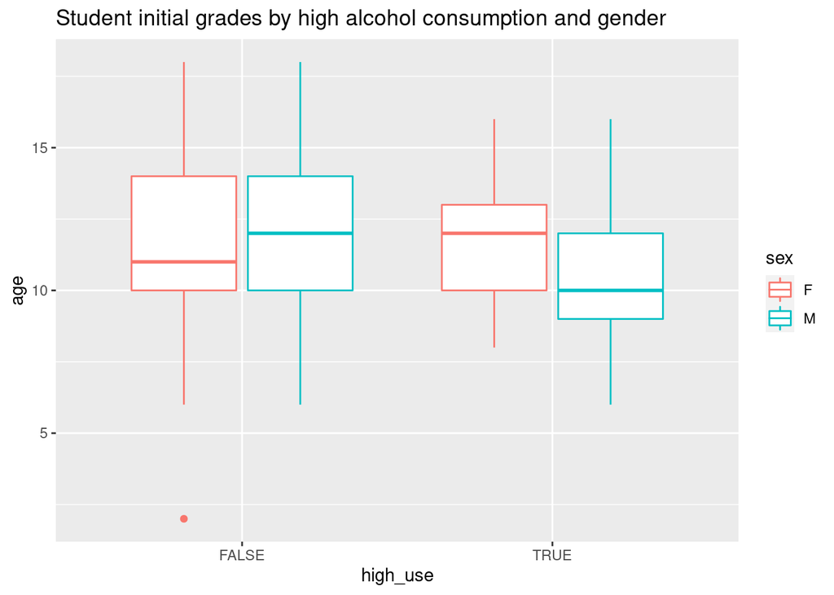

```r
g1 <- ggplot(alc, aes(x = high_use, y = G1, col = sex))
g1 + geom_boxplot() + ylab("age")+ggtitle("Student initial grades by high alcohol consumption and gender")
```

Then let’s see the age distribution within high and low users.

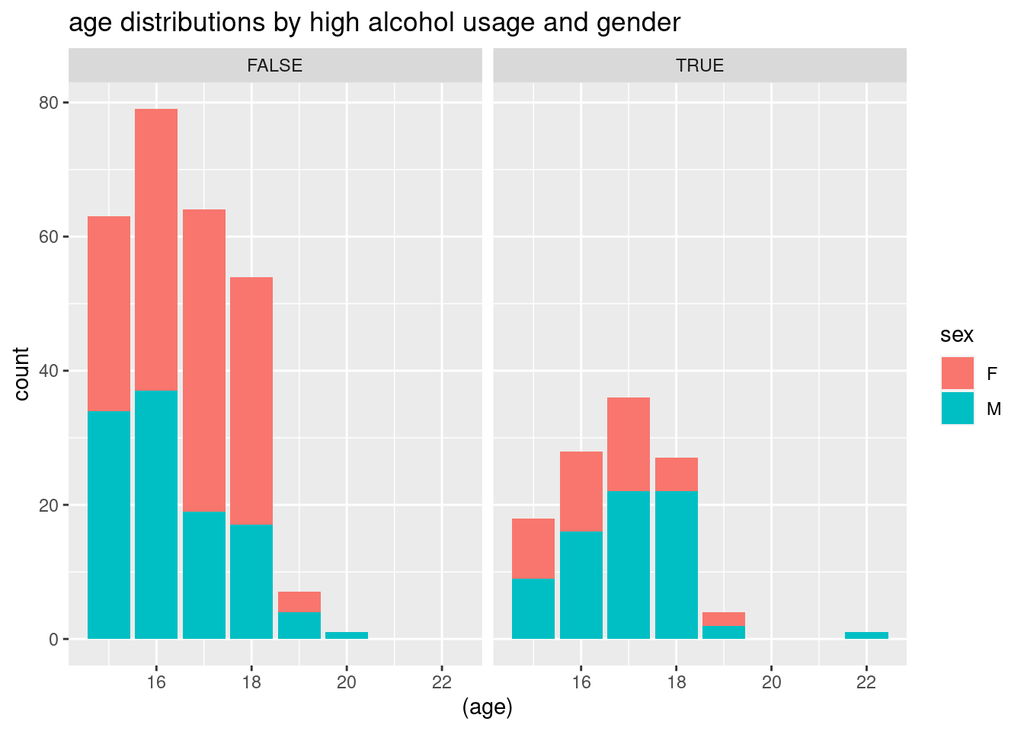

```r
# initialize a plot of 'high_use'
g2 <- ggplot(alc, aes(x=(age), fill=sex))

g2 + facet_wrap("high_use")  + geom_bar() + ggtitle("age distributions by high alcohol usage and gender")
```

Seems like the age distribution might be relevantly different in the high alcohol consumers.

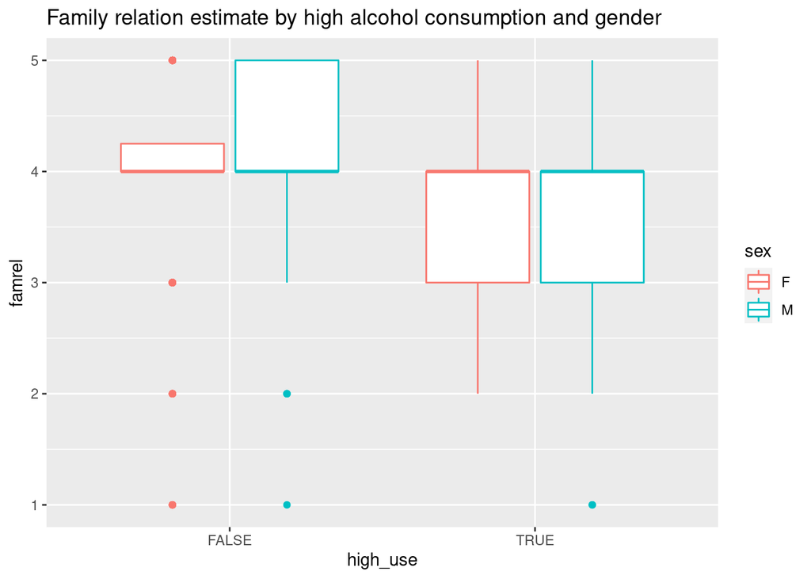

```r
g1 <- ggplot(alc, aes(x = high_use, y = famrel, col = sex))
g1 + geom_boxplot() + ylab("famrel")+ggtitle("Family relation estimate by high alcohol consumption and gender")
```

These seem promising to the hypothesis model.

## Logistic regression

Now I’m about to do a fitting with the binomial distribution (high alcohol consumers vs the control group)

```r
# find the model with glm()
m <- glm(high_use ~ age + sex + G1 + famrel, data = alc, family = "binomial")

summary(m)
```

```
##
## Call:
## glm(formula = high_use ~ age + sex + G1 + famrel, family = "binomial",
##     data = alc)
##
## Deviance Residuals:
##     Min       1Q   Median       3Q      Max
## -1.4499  -0.8193  -0.6569   1.1384   2.1599
##
## Coefficients:
##             Estimate Std. Error z value Pr(>|z|)
## (Intercept)  -1.9968     1.8764  -1.064   0.2872
## age           0.1917     0.1007   1.903   0.0571 .
## sexM          0.9436     0.2378   3.967 7.26e-05 ***
## G1           -0.1141     0.0447  -2.553   0.0107 *
## famrel       -0.3207     0.1262  -2.542   0.0110 *
## ---
## Signif. codes:  0 '***' 0.001 '**' 0.01 '*' 0.05 '.' 0.1 ' ' 1
##
## (Dispersion parameter for binomial family taken to be 1)
##
##     Null deviance: 465.68  on 381  degrees of freedom
## Residual deviance: 432.29  on 377  degrees of freedom
## AIC: 442.29
##
## Number of Fisher Scoring iterations: 4
```

```r
coef(m)
```

```
## (Intercept)         age        sexM          G1      famrel
##  -1.9968299   0.1916833   0.9435755  -0.1141214  -0.3207391
```

All the coefficients seem to be somewhat relevant to predicting high usage. This can be more easily understood as odds ratios, which are the exponents of the coefficients.

**Odds ratios** and their confidence intervals:

```r
# compute odds ratios (OR)
OR <- coef(m) %>% exp

# compute confidence intervals (CI)
CI <- confint(m) %>% exp
cbind(OR, CI)
```

```
##                    OR       2.5 %    97.5 %
## (Intercept) 0.1357650 0.003360881 5.3701291
## age         1.2112868 0.995467029 1.4791035
## sexM        2.5691511 1.620172718 4.1227535
## G1          0.8921496 0.815955982 0.9726699
## famrel      0.7256125 0.565422154 0.9289606
```

**Analysis of the fitted model:** It seems like the good family relations reduce the high alcohol consumption. Higher age and male gender seems also to be an inducing factor to high consumption. Higher grades at first period studies also give a hint towards lesser probable high consumption.

All in all, we’ll keep these coefficients as the factors of our prediction.

## Cross tabulation of a prediction model

First, I create a prediction and probability column, based on the fitting.

```r
# predict() the probability of high_use
probabilities <- predict(m, type = "response")
```

Adding the predicted probabilities to ‘alc’ and using the probabilities to make a prediction of high_use:

```r
alc <- mutate(alc, probability = probabilities)
alc <- mutate(alc, prediction = probability > 0.5)
```

To understand and examine the prediction, let’s see the last ten original classes, predicted probabilities, and “high use” class predictions:

```r
select(alc, age, sex, G1, famrel,high_use, probability, prediction) %>% tail(10)
```

```
##     age sex G1 famrel high_use probability prediction
## 373  19   M  6      4    FALSE   0.6504559       TRUE
## 374  18   M  6      5     TRUE   0.5271286       TRUE
## 375  18   F 12      5    FALSE   0.1795082      FALSE
## 376  18   F  6      4    FALSE   0.3742059      FALSE
## 377  19   F  8      5    FALSE   0.2949394      FALSE
## 378  18   F 11      4    FALSE   0.2525945      FALSE
## 379  18   F  6      2    FALSE   0.5317729       TRUE
## 380  18   F  8      1    FALSE   0.5547198       TRUE
## 381  17   M 12      2     TRUE   0.5484541       TRUE
## 382  18   M 10      4     TRUE   0.4932191      FALSE
```

**Now let’s tabulate the target variable versus the predictions:**

```r
table(high_use = alc$high_use, prediction = alc$prediction)
```

```
##         prediction
## high_use FALSE TRUE
##    FALSE   249   19
##    TRUE     93   21
```

**We can be pretty OK with this.** There is always a bit uncertainty but the model seems OK. A graphic evaluation of the probability and prediction results below:

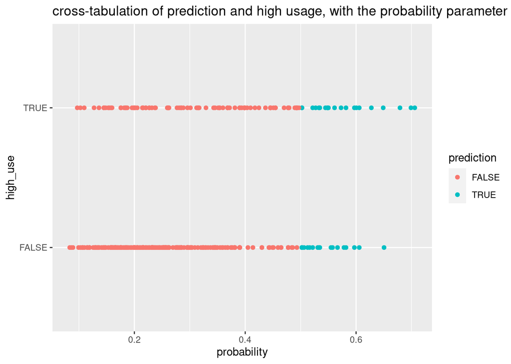

```r
g <- ggplot(alc, aes(x = probability, y = high_use, col = prediction))
g + geom_point() + ggtitle("cross-tabulation of prediction and high usage, with the probability parameter")
```

## 10-fold cross-validation of the prediction

First let’s define a loss function (which is the average error in prediction).

```r
# define a loss function (average prediction error)
loss_func <- function(class, prob) {
  n_wrong <- abs(class - prob) > 0.5
  mean(n_wrong)
}

loss_func(class = alc$high_use, prob = alc$probability)
```

```
## [1] 0.2931937
```

The computed average number of wrong predictions in the (training) data is around 0.29.

Next, we’ll do a ten-fold cross-validation with resampling

```r
library(boot)
cv <- cv.glm(data = alc, cost = loss_func, glmfit = m, K = 10)

cv$delta[1]
```

```
## [1] 0.3036649
```

The average number of wrong predictions in the cross validation is not too small (about 3 wrong out of 10) but we’re quite happy with this.